# Heart Disease Prediction

Aung Thura Htoo

2025-01-11

Millions of people develop some sort of heart disease every year, and heart disease is the biggest killer of both men and women in the United States and around the world. Statistical analysis has identified many risk factors associated with heart disease, such as age, blood pressure, total cholesterol, diabetes, hypertension, family history of heart disease, obesity, lack of physical exercise, and more.

In this project, I will use the dataset from **the Cleveland heart disease dataset** (provided by DataCamp) to predict a model that can predict the likelihood of heart disease from its associated factors that are significant.

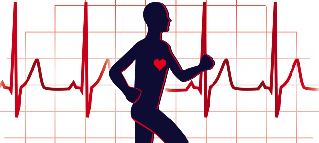

1. **Install or Load the necessary packages**

```r
library(tidyverse)
library(yardstick)
library(Metrics)
library(caret)
```

2. **Load the Cleveland heart disease dataset**

```r
# Define the file path
file_path <- "/Users/thandarmoe/Library/Mobile Documents/com~apple~CloudDocs/teaching/Cloud/me/R-Language/Practice/Dataset/Cleveland_hd.csv"

# Load the CSV file
hd_data <- read.csv(file_path)

# Inspect the first five rows
head(hd_data, 5)
```

```
##   age sex cp trestbps chol fbs restecg thalach exang oldpeak slope ca thal
## 1  63   1  1      145  233   1       2     150     0     2.3     3  0    6
## 2  67   1  4      160  286   0       2     108     1     1.5     2  3    3
## 3  67   1  4      120  229   0       2     129     1     2.6     2  2    7
## 4  37   1  3      130  250   0       0     187     0     3.5     3  0    3
## 5  41   0  2      130  204   0       2     172     0     1.4     1  0    3
##   class
## 1     0
## 2     2
## 3     1
## 4     0
## 5     0
```

```r
str(hd_data)
```

```
## 'data.frame':    303 obs. of  14 variables:
##  $ age     : int  63 67 67 37 41 56 62 57 63 53 ...
##  $ sex     : int  1 1 1 1 0 1 0 0 1 1 ...
##  $ cp      : int  1 4 4 3 2 2 4 4 4 4 ...
##  $ trestbps: int  145 160 120 130 130 120 140 120 130 140 ...
##  $ chol    : int  233 286 229 250 204 236 268 354 254 203 ...
##  $ fbs     : int  1 0 0 0 0 0 0 0 0 1 ...
##  $ restecg : int  2 2 2 0 2 0 2 0 2 2 ...
##  $ thalach : int  150 108 129 187 172 178 160 163 147 155 ...
##  $ exang   : int  0 1 1 0 0 0 0 1 0 1 ...
##  $ oldpeak : num  2.3 1.5 2.6 3.5 1.4 0.8 3.6 0.6 1.4 3.1 ...
##  $ slope   : int  3 2 2 3 1 1 3 1 2 3 ...
##  $ ca      : int  0 3 2 0 0 0 2 0 1 0 ...
##  $ thal    : int  6 3 7 3 3 3 3 3 7 7 ...
##  $ class   : int  0 2 1 0 0 0 3 0 2 1 ...
```

3. **Clean the data**

```r
## (Clening the data)

#to check if there are missing values
sapply(hd_data, function(x) sum(is.na(x)))
```

```
##      age      sex       cp trestbps     chol      fbs  restecg  thalach
##        0        0        0        0        0        0        0        0
##    exang  oldpeak    slope       ca     thal    class
##        0        0        0        4        2        0
```

```r
hd_data <- na.omit(hd_data)
```

4. **Transform the data**

```r
##(Transform the data)

hd_data$sex_n[hd_data$sex == "0"] <- "female"
hd_data$sex_n[hd_data$sex == "1"] <- "male"

hd_data$cp_n[hd_data$cp == "1"] <- "ty angina"
hd_data$cp_n[hd_data$cp == "2"] <- "atyp angina"
hd_data$cp_n[hd_data$cp == "3"] <- "non-ang pain"
hd_data$cp_n[hd_data$cp == "4"] <- "asym"

hd_data$fbs_n[hd_data$fbs == "0"] <- "no high glu"
hd_data$fbs_n[hd_data$fbs == "1"] <- "high glu"

hd_data$restecg_n[hd_data$restecg == "0"] <- "normal"
hd_data$restecg_n[hd_data$restecg == "1"] <- "ST-T abn"
hd_data$restecg_n[hd_data$restecg == "2"] <- "LVH"

hd_data$exang_n[hd_data$exang == "0"] <- "no exang"
hd_data$exang_n[hd_data$exang == "1"] <- "exang"

hd_data$slope_n[hd_data$slope == "1"] <- "up"
hd_data$slope_n[hd_data$slope == "2"] <- "flat"
hd_data$slope_n[hd_data$slope == "3"] <- "down"

hd_data$thal_n[hd_data$thal == "3"] <- "normal"
hd_data$thal_n[hd_data$thal == "6"] <- "fixed defect"
hd_data$thal_n[hd_data$thal == "7"] <- "rev defect"

hd_data$class_n <- ifelse(hd_data$class == 0, 0, 1)

# factorize

hd_data$sex_n <- factor(hd_data$sex_n, levels = c("female", "male"))

hd_data$cp_n <- factor(hd_data$cp_n, levels = c("ty angina", "atyp angina","non-ang pain", "asym"))

hd_data$fbs_n <- factor(hd_data$fbs_n, levels = c("no high glu", "high glu"))

hd_data$restecg_n <- factor(hd_data$restecg_n, levels = c("normal", "ST-T abn", "LVH"))

hd_data$exang_n <- factor(hd_data$exang_n, levels = c("no exang", "exang"))

hd_data$slope_n <- factor(hd_data$slope_n, levels = c("up", "flat","down"))

hd_data$thal_n <- factor(hd_data$thal_n, levels = c("normal", "fixed defect","rev defect"))

str(hd_data)
```

```
## 'data.frame':    297 obs. of  22 variables:
##  $ age      : int  63 67 67 37 41 56 62 57 63 53 ...
##  $ sex      : int  1 1 1 1 0 1 0 0 1 1 ...
##  $ cp       : int  1 4 4 3 2 2 4 4 4 4 ...
##  $ trestbps : int  145 160 120 130 130 120 140 120 130 140 ...
##  $ chol     : int  233 286 229 250 204 236 268 354 254 203 ...
##  $ fbs      : int  1 0 0 0 0 0 0 0 0 1 ...
##  $ restecg  : int  2 2 2 0 2 0 2 0 2 2 ...
##  $ thalach  : int  150 108 129 187 172 178 160 163 147 155 ...
##  $ exang    : int  0 1 1 0 0 0 0 1 0 1 ...
##  $ oldpeak  : num  2.3 1.5 2.6 3.5 1.4 0.8 3.6 0.6 1.4 3.1 ...
##  $ slope    : int  3 2 2 3 1 1 3 1 2 3 ...
##  $ ca       : int  0 3 2 0 0 0 2 0 1 0 ...
##  $ thal     : int  6 3 7 3 3 3 3 3 7 7 ...
##  $ class    : int  0 2 1 0 0 0 3 0 2 1 ...
##  $ sex_n    : Factor w/ 2 levels "female","male": 2 2 2 2 1 2 1 1 2 2 ...
##  $ cp_n     : Factor w/ 4 levels "ty angina","atyp angina",..: 1 4 4 3 2 2 4 4 4 4 ...
##  $ fbs_n    : Factor w/ 2 levels "no high glu",..: 2 1 1 1 1 1 1 1 1 2 ...
##  $ restecg_n: Factor w/ 3 levels "normal","ST-T abn",..: 3 3 3 1 3 1 3 1 3 3 ...
##  $ exang_n  : Factor w/ 2 levels "no exang","exang": 1 2 2 1 1 1 1 2 1 2 ...
##  $ slope_n  : Factor w/ 3 levels "up","flat","down": 3 2 2 3 1 1 3 1 2 3 ...
##  $ thal_n   : Factor w/ 3 levels "normal","fixed defect",..: 2 1 3 1 1 1 1 1 3 3 ...
##  $ class_n  : num  0 1 1 0 0 0 1 0 1 1 ...
##  - attr(*, "na.action")= 'omit' Named int [1:6] 88 167 193 267 288 303
##   ..- attr(*, "names")= chr [1:6] "88" "167" "193" "267" ...
```

```r
head(hd_data,5)
```

```
##   age sex cp trestbps chol fbs restecg thalach exang oldpeak slope ca thal
## 1  63   1  1      145  233   1       2     150     0     2.3     3  0    6
## 2  67   1  4      160  286   0       2     108     1     1.5     2  3    3
## 3  67   1  4      120  229   0       2     129     1     2.6     2  2    7
## 4  37   1  3      130  250   0       0     187     0     3.5     3  0    3
## 5  41   0  2      130  204   0       2     172     0     1.4     1  0    3
##   class  sex_n         cp_n       fbs_n restecg_n  exang_n slope_n       thal_n
## 1     0   male    ty angina    high glu       LVH no exang    down fixed defect
## 2     2   male         asym no high glu       LVH    exang    flat       normal
## 3     1   male         asym no high glu       LVH    exang    flat   rev defect
## 4     0   male non-ang pain no high glu    normal no exang    down       normal
## 5     0 female  atyp angina no high glu       LVH no exang      up       normal
##   class_n
## 1       0
## 2       1
## 3       1
## 4       0
## 5       0
```

5. **Stepwise Multiple Regression Analysis**

```r
## Stepwise Multiple Regression Analysis

mylogit <- glm (class_n ~ age+sex_n+cp_n+trestbps+chol+fbs_n+restecg_n+thalach+exang_n+oldpeak+slope_n+ca+thal_n,  data = hd_data, family = "binomial")
summary(mylogit)
```

```
##
## Call:
## glm(formula = class_n ~ age + sex_n + cp_n + trestbps + chol +
##     fbs_n + restecg_n + thalach + exang_n + oldpeak + slope_n +
##     ca + thal_n, family = "binomial", data = hd_data)
##
## Coefficients:
##                     Estimate Std. Error z value Pr(>|z|)
## (Intercept)        -6.029468   2.891768  -2.085  0.03707 *
## age                -0.013763   0.024745  -0.556  0.57808
## sex_nmale           1.546014   0.529995   2.917  0.00353 **
## cp_natyp angina     1.239566   0.770874   1.608  0.10784
## cp_nnon-ang pain    0.245959   0.663312   0.371  0.71078
## cp_nasym            2.086480   0.666547   3.130  0.00175 **
## trestbps            0.024364   0.011269   2.162  0.03062 *
## chol                0.004448   0.003993   1.114  0.26526
## fbs_nhigh glu      -0.596246   0.607848  -0.981  0.32664
## restecg_nST-T abn   0.810202   2.435102   0.333  0.73935
## restecg_nLVH        0.473895   0.383518   1.236  0.21659
## thalach            -0.017723   0.011109  -1.595  0.11065
## exang_nexang        0.709456   0.440018   1.612  0.10689
## oldpeak             0.357875   0.230070   1.556  0.11983
## slope_nflat         1.155286   0.473794   2.438  0.01475 *
## slope_ndown         0.525147   0.919661   0.571  0.56798
## ca                  1.311510   0.279276   4.696 2.65e-06 ***
## thal_nfixed defect -0.010974   0.790210  -0.014  0.98892
## thal_nrev defect    1.392715   0.425194   3.275  0.00105 **
## ---
## Signif. codes:  0 '***' 0.001 '**' 0.01 '*' 0.05 '.' 0.1 ' ' 1
##
## (Dispersion parameter for binomial family taken to be 1)
##
##     Null deviance: 409.95  on 296  degrees of freedom
## Residual deviance: 191.64  on 278  degrees of freedom
## AIC: 229.64
##
## Number of Fisher Scoring iterations: 6
```

```r
#remove the least significant variables

mylogit <- glm (class_n ~ age+sex_n+cp_n+trestbps+chol+fbs_n+restecg_n+thalach+exang_n+oldpeak+slope_n+ca+thal_n,  data = hd_data, family = "binomial")
summary(mylogit)
```

```
##
## Call:
## glm(formula = class_n ~ age + sex_n + cp_n + trestbps + chol +
##     fbs_n + restecg_n + thalach + exang_n + oldpeak + slope_n +
##     ca + thal_n, family = "binomial", data = hd_data)
##
## Coefficients:
##                     Estimate Std. Error z value Pr(>|z|)
## (Intercept)        -6.029468   2.891768  -2.085  0.03707 *
## age                -0.013763   0.024745  -0.556  0.57808
## sex_nmale           1.546014   0.529995   2.917  0.00353 **
## cp_natyp angina     1.239566   0.770874   1.608  0.10784
## cp_nnon-ang pain    0.245959   0.663312   0.371  0.71078
## cp_nasym            2.086480   0.666547   3.130  0.00175 **
## trestbps            0.024364   0.011269   2.162  0.03062 *
## chol                0.004448   0.003993   1.114  0.26526
## fbs_nhigh glu      -0.596246   0.607848  -0.981  0.32664
## restecg_nST-T abn   0.810202   2.435102   0.333  0.73935
## restecg_nLVH        0.473895   0.383518   1.236  0.21659
## thalach            -0.017723   0.011109  -1.595  0.11065
## exang_nexang        0.709456   0.440018   1.612  0.10689
## oldpeak             0.357875   0.230070   1.556  0.11983
## slope_nflat         1.155286   0.473794   2.438  0.01475 *
## slope_ndown         0.525147   0.919661   0.571  0.56798
## ca                  1.311510   0.279276   4.696 2.65e-06 ***
## thal_nfixed defect -0.010974   0.790210  -0.014  0.98892
## thal_nrev defect    1.392715   0.425194   3.275  0.00105 **
## ---
## Signif. codes:  0 '***' 0.001 '**' 0.01 '*' 0.05 '.' 0.1 ' ' 1
##
## (Dispersion parameter for binomial family taken to be 1)
##
##     Null deviance: 409.95  on 296  degrees of freedom
## Residual deviance: 191.64  on 278  degrees of freedom
## AIC: 229.64
##
## Number of Fisher Scoring iterations: 6
```

```r
mylogit <- glm (class_n ~ age+sex_n+cp_n+trestbps+thalach+exang_n+oldpeak+slope_n+ca+thal_n,  data = hd_data, family = "binomial")
summary(mylogit)
```

```
##
## Call:
## glm(formula = class_n ~ age + sex_n + cp_n + trestbps + thalach +
##     exang_n + oldpeak + slope_n + ca + thal_n, family = "binomial",
##     data = hd_data)
##
## Coefficients:
##                     Estimate Std. Error z value Pr(>|z|)
## (Intercept)        -5.109337   2.778797  -1.839 0.065961 .
## age                -0.008822   0.024274  -0.363 0.716275
## sex_nmale           1.406704   0.499174   2.818 0.004831 **
## cp_natyp angina     1.288744   0.758338   1.699 0.089238 .
## cp_nnon-ang pain    0.200958   0.649997   0.309 0.757194
## cp_nasym            2.162558   0.658355   3.285 0.001021 **
## trestbps            0.023991   0.010808   2.220 0.026437 *
## thalach            -0.016402   0.010884  -1.507 0.131803
## exang_nexang        0.659848   0.433832   1.521 0.128266
## oldpeak             0.388212   0.222838   1.742 0.081486 .
## slope_nflat         1.209694   0.465448   2.599 0.009350 **
## slope_ndown         0.453737   0.893315   0.508 0.611506
## ca                  1.264412   0.268225   4.714 2.43e-06 ***
## thal_nfixed defect -0.240894   0.762266  -0.316 0.751984
## thal_nrev defect    1.365777   0.414886   3.292 0.000995 ***
## ---
## Signif. codes:  0 '***' 0.001 '**' 0.01 '*' 0.05 '.' 0.1 ' ' 1
##
## (Dispersion parameter for binomial family taken to be 1)
##
##     Null deviance: 409.95  on 296  degrees of freedom
## Residual deviance: 195.85  on 282  degrees of freedom
## AIC: 225.85
##
## Number of Fisher Scoring iterations: 6
```

```r
mylogit <- glm (class_n ~ sex_n+cp_n+trestbps+oldpeak+slope_n+ca+thal_n,  data = hd_data, family = "binomial")
summary(mylogit)
```

```
##
## Call:
## glm(formula = class_n ~ sex_n + cp_n + trestbps + oldpeak + slope_n +
##     ca + thal_n, family = "binomial", data = hd_data)
##
## Coefficients:
##                     Estimate Std. Error z value Pr(>|z|)
## (Intercept)        -8.101290   1.793804  -4.516 6.29e-06 ***
## sex_nmale           1.337975   0.477314   2.803 0.005061 **
## cp_natyp angina     1.310229   0.766155   1.710 0.087241 .
## cp_nnon-ang pain    0.283613   0.660958   0.429 0.667855
## cp_nasym            2.571164   0.653209   3.936 8.28e-05 ***
## trestbps            0.022347   0.010340   2.161 0.030676 *
## oldpeak             0.439985   0.215974   2.037 0.041629 *
## slope_nflat         1.491612   0.442915   3.368 0.000758 ***
## slope_ndown         0.623749   0.837960   0.744 0.456655
## ca                  1.279213   0.254868   5.019 5.19e-07 ***
## thal_nfixed defect -0.007463   0.732901  -0.010 0.991876
## thal_nrev defect    1.498453   0.405023   3.700 0.000216 ***
## ---
## Signif. codes:  0 '***' 0.001 '**' 0.01 '*' 0.05 '.' 0.1 ' ' 1
##
## (Dispersion parameter for binomial family taken to be 1)
##
##     Null deviance: 409.95  on 296  degrees of freedom
## Residual deviance: 201.57  on 285  degrees of freedom
## AIC: 225.57
##
## Number of Fisher Scoring iterations: 6
```

6. **Forward Selection**

```r
## Forward Selection

fullmodel <- glm (class_n ~ age+sex_n+cp_n+trestbps+chol+fbs_n+restecg_n+thalach+exang_n+oldpeak+slope_n+ca+thal_n,  data = hd_data, family = "binomial")
nothing <- glm(class_n ~ 1, data = hd_data, family = "binomial")
forwards = step(nothing, scope = list(lower=formula(nothing), upper=formula(fullmodel)), direction = "forward")
```

```
## Start:  AIC=411.95
## class_n ~ 1
##
##             Df Deviance    AIC
## + thal_n     2   323.39 329.39
## + cp_n       3   328.75 336.75
## + ca         1   339.42 343.42
## + oldpeak    1   350.48 354.48
## + thalach    1   351.97 355.97
## + exang_n    1   355.48 359.48
## + slope_n    2   365.16 371.16
## + sex_n      1   386.12 390.12
## + age        1   394.25 398.25
## + restecg_n  2   400.28 406.28
## + trestbps   1   402.88 406.88
## <none>           409.95 411.95
## + chol       1   408.03 412.03
## + fbs_n      1   409.94 413.94
##
## Step:  AIC=329.39
## class_n ~ thal_n
##
##             Df Deviance    AIC
## + ca         1   273.59 281.59
## + cp_n       3   275.86 287.86
## + thalach    1   288.27 296.27
## + oldpeak    1   294.27 302.27
## + exang_n    1   295.84 303.84
## + slope_n    2   300.98 310.98
## + age        1   312.61 320.61
## + restecg_n  2   311.48 321.48
## + sex_n      1   320.64 328.64
## + trestbps   1   320.68 328.68
## + chol       1   320.89 328.89
## <none>           323.39 329.39
## + fbs_n      1   322.99 330.99
##
## Step:  AIC=281.59
## class_n ~ thal_n + ca
##
```

[output cut: 91 more lines]

```
## + chol       1   197.12 225.12
## + fbs_n      1   197.27 225.27
## + restecg_n  2   196.13 226.13
## + age        1   198.20 226.20
##
## Step:  AIC=223.98
## class_n ~ thal_n + ca + cp_n + oldpeak + slope_n + sex_n + trestbps +
##     exang_n + thalach
##
##             Df Deviance    AIC
## <none>           195.98 223.98
## + chol       1   194.47 224.47
## + fbs_n      1   195.13 225.13
## + age        1   195.85 225.85
## + restecg_n  2   193.96 225.96
```

7. **Backward Selection**

```r
##Backward Selection

fullmodel <- glm (class_n ~ age+sex_n+cp_n+trestbps+chol+fbs_n+restecg_n+thalach+exang_n+oldpeak+slope_n+ca+thal_n,  data = hd_data, family = "binomial")
backwards = step(fullmodel, direction = "backward")
```

```
## Start:  AIC=229.64
## class_n ~ age + sex_n + cp_n + trestbps + chol + fbs_n + restecg_n +
##     thalach + exang_n + oldpeak + slope_n + ca + thal_n
##
##             Df Deviance    AIC
## - restecg_n  2   193.24 227.24
## - age        1   191.95 227.95
## - fbs_n      1   192.63 228.63
## - chol       1   192.86 228.86
## <none>           191.64 229.64
## - oldpeak    1   194.15 230.15
## - exang_n    1   194.21 230.21
## - thalach    1   194.28 230.28
## - slope_n    2   197.96 231.96
## - trestbps   1   196.53 232.53
## - sex_n      1   200.86 236.86
## - thal_n     2   203.93 237.93
## - cp_n       3   210.79 242.79
## - ca         1   220.00 256.00
##
## Step:  AIC=227.24
## class_n ~ age + sex_n + cp_n + trestbps + chol + fbs_n + thalach +
##     exang_n + oldpeak + slope_n + ca + thal_n
##
##            Df Deviance    AIC
## - age       1   193.50 225.50
## - fbs_n     1   194.20 226.20
## - chol      1   195.01 227.01
## <none>          193.24 227.24
## - oldpeak   1   195.69 227.69
## - exang_n   1   195.77 227.77
## - thalach   1   195.98 227.98
## - slope_n   2   200.43 230.43
## - trestbps  1   198.76 230.76
## - thal_n    2   204.85 234.85
## - sex_n     1   203.63 235.63
## - cp_n      3   212.30 240.30
## - ca        1   222.28 254.28
##
## Step:  AIC=225.5
```

[output cut: 34 more lines]

```
## Step:  AIC=223.98
## class_n ~ sex_n + cp_n + trestbps + thalach + exang_n + oldpeak +
##     slope_n + ca + thal_n
##
##            Df Deviance    AIC
## <none>          195.98 223.98
## - thalach   1   198.25 224.25
## - exang_n   1   198.34 224.34
## - oldpeak   1   199.23 225.23
## - trestbps  1   201.11 227.11
## - slope_n   2   203.20 227.20
## - sex_n     1   205.07 231.07
## - thal_n    2   209.17 233.17
## - cp_n      3   218.57 240.57
## - ca        1   225.74 251.74
```

After running step-wise, forward, and backward selection, **step-wise selection** is parsimonious and biological more plausible, and accordingly, it is selected.

8. **Prediction**

Predict the outcome of developing heart disease using the model.

Set the threshold to 0.5, meaning that if the predicted probability exceeds 0.5, it will regard as heart disease.

```r
# Confusion Matrix

# Generate predictions using the logistic regression model
hd_data$glm.probs <- predict(mylogit, type = "response")

# Classify predictions as "hd_ds" or "no hd_ds" based on a threshold of 0.5
hd_data$glm.pred <- ifelse(hd_data$glm.probs > 0.5, "hd_ds", "no hd_ds")

# Convert the classification results to a factor
hd_data$glm.pred <- factor(hd_data$glm.pred, levels = c("hd_ds", "no hd_ds"))

# Display the first few rows of the birth dataframe
head(hd_data, 5) %>% select(class_n, glm.probs, glm.pred)
```

```
##   class_n glm.probs glm.pred
## 1       0 0.1307061 no hd_ds
## 2       1 0.9953795    hd_ds
## 3       1 0.9944144    hd_ds
## 4       0 0.1960954 no hd_ds
## 5       0 0.0366164 no hd_ds
```

9. **Accuracy**

```r
# Actual outcomes
actual <- hd_data$class_n
prediction <- ifelse(hd_data$glm.probs > 0.5, "1", "0")

# Accuracy
accuracy <- Metrics::accuracy(actual, prediction)
accuracy
```

```
## [1] 0.8518519
```

10. **Confusion Matrix**

```r
# Generate the actual and prediction labels
results <- tibble(
  truth = factor(ifelse(actual == 1, "hd_ds", "no_hd_ds"), levels = c("no_hd_ds", "hd_ds")),
  estimate = factor(ifelse(prediction == 1, "hd_ds", "no_hd_ds"), levels = c("no_hd_ds", "hd_ds"))
)

# Confusion matrix
confusion <- yardstick::conf_mat(results, truth = truth, estimate = estimate)
confusion
```

```
##           Truth
## Prediction no_hd_ds hd_ds
##   no_hd_ds      142    26
##   hd_ds          18   111
```

True Positive: 111

False Positive: 18

True Negative: 142

False Negative: 26

Sensitivity: TP/(TP+FN) = 0.81

Specificity: TN/(TN+FP) = 0.88

```r
actual <- factor(hd_data$class_n, levels = c("0", "1"))
predicted <- factor(prediction, levels = c("0", "1"))

confusionMatrix(predicted, actual, positive = "1")
```

```
## Confusion Matrix and Statistics
##
##           Reference
## Prediction   0   1
##          0 142  26
##          1  18 111
##
##                Accuracy : 0.8519
##                  95% CI : (0.8063, 0.8902)
##     No Information Rate : 0.5387
##     P-Value [Acc > NIR] : <2e-16
##
##                   Kappa : 0.7007
##
##  Mcnemar's Test P-Value : 0.2913
##
##             Sensitivity : 0.8102
##             Specificity : 0.8875
##          Pos Pred Value : 0.8605
##          Neg Pred Value : 0.8452
##              Prevalence : 0.4613
##          Detection Rate : 0.3737
##    Detection Prevalence : 0.4343
##       Balanced Accuracy : 0.8489
##
##        'Positive' Class : 1
##
```